# Highlighting content

In this notebook, I analyse if participants who used the prototype’s “highlight” function more differ from participants who used it less in terms of their TA-EG, SUS, NASA-TLX values or performance.

## Load packages and data

```r
library(WRS2)
library(rcompanion)
library(feather)
library(ggplot2)
library(plyr)
library(ez)
library(schoRsch)
library(MASS)
library(car)
library(tidyverse)
library(ggpubr)
library(rstatix)
```

Load a dataframe with participants’ interactions with the system.

```r
df_useractions <- read_feather(path = here('../../data_frames/results_test_02-04-2020_user_actions.file'))
```

```
Coercing int64 to doubleCoercing int64 to doubleCoercing int64 to doubleCoercing int64 to doubleCoercing int64 to doubleCoercing int64 to doubleCoercing int64 to double
```

Load dataframe with the remaining experimental data in wide format.

```r
df_wide <- read_feather(path = here('../../data_frames/results_test_18-03-2020.file'))
```

```
Coercing int64 to doubleCoercing int64 to doubleCoercing int64 to doubleCoercing int64 to doubleCoercing int64 to doubleCoercing int64 to doubleCoercing int64 to doubleCoercing int64 to doubleCoercing int64 to doubleCoercing int64 to doubleCoercing int64 to double
```

## Prepare the data

### Assign participants to the experimental group

- version 1 and 2 –> control group
- version 3 und 4 –> experimental group context free
- version 5 und 6–> experimental group context sensitive

```r
df_wide$group <- ifelse((df_wide$version == 5 | df_wide$version == 6), 'context-sensitive experimental group', ifelse((df_wide$version == 1 | df_wide$version == 2), 'controlgroup', 'context-free experimental group'))
df_useractions$group <- ifelse((df_useractions$version == 5 | df_useractions$version == 6), 'context-sensitive experimental group', ifelse((df_useractions$version == 1 | df_useractions$version == 2), 'controlgroup', 'context-free experimental group'))
```

```r
# Convert trial, group and subject number to factors in each dataframe
df_useractions$trial <- factor(df_useractions$trial, levels = c("tutorial", "warm up", "trial 1", "trial 2", "trial 3"))
df_useractions$group <- factor(df_useractions$group)
df_useractions$partnr <- factor(df_useractions$partnr)
df_wide$group <- factor(df_wide$group)
df_wide$partnr <- factor(df_wide$partnr)
```

### Converting the dataframes

For participants’ interactions with the prototype, we only want the data from participants in the experimental groups whilst working on the experimental tasks.

```r
# exclude interactions during tutorial and warm up
df_trial <- df_useractions[!(df_useractions$trial=="tutorial" | df_useractions$trial=="warm up"), ]
```

```r
# exclude data from the control group
df <- df_trial[!(df_trial$group=="controlgroup"), ]
```

```r
# convert df to wide format
df_w <- pivot_wider(data = df,
                           id_cols = partnr,
                           names_from = trial,
                           values_from = c("add_note", "add_to_context", "highlights", "open_website_from_sidebar", "remove_activity", "remove_from_context"))
```

```r
# include how often participants used the highlights function in total
df_w$highlight <- rowSums(df_w[,c("highlights_trial 1", "highlights_trial 2", "highlights_trial 3")])
```

```r
# include a performance measure
df_wide <- transform(df_wide, perf = mistakes_after_interruption / entries_after_interruption)
```

```r
# merge the dataframes with participants' interactions with the prototype and dependent variables
df_h <- merge(df_wide[,c("partnr", "NASATLX_1", "NASATLX_2", "NASATLX_3", "NASATLX_4", "SUS", "TAEG", "group", "perf")], df_w, by="partnr")
```

We exclude participants 11 and 26 for analysing performance, as we excluded them for the hypothesis testing for performance.

```r
exclude <- list(11, 26)
df_perf <- subset(df_h, !(df_h$partnr %in% exclude))
```

## Analyse data

### Do participants who used the prototype more have different characteristics?

#### How often have participants used the highlight function?

```r
table(df_h$highlight)
```

```
 0  1  2  4  6  7  8  9 10 12 14
14  1  4  5  3  1  2  1  1  1  1
```

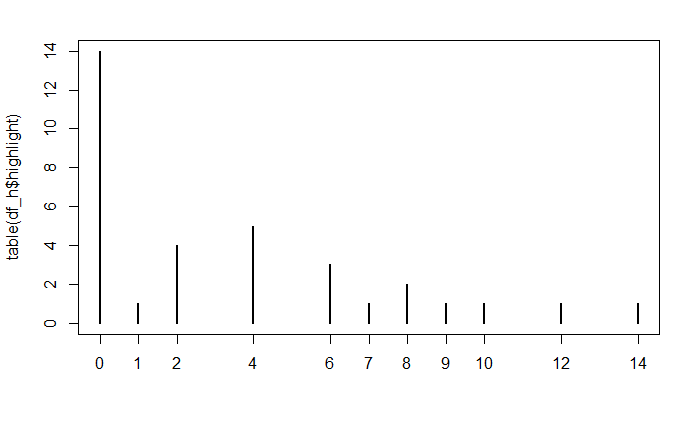

```r
plot(table(df_h$highlight))
```

```r
median(df_h$highlight)
```

```
[1] 2
```

```r
mean(df_h$highlight)
```

```
[1] 3.382353
```

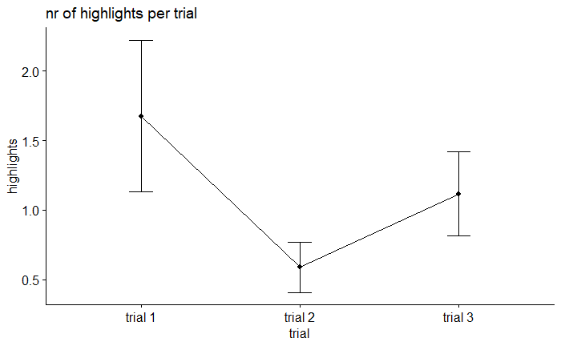

```r
ggline(df, x = "trial", y ="highlights",
       add = c("mean_se"),
       title = "nr of highlights per trial")
```

#### correlations with TA-EG, SUS and NASA-TLX

##### TA-EG (n.s.)

There is no significant correlation between frequency of use of the highlight function and participants’ TA-EG.

```r
cor.test(df_h$TAEG, df_h$highlight)
```

```
    Pearson's product-moment correlation

data:  df_h$TAEG and df_h$highlight
t = -0.78655, df = 32, p-value = 0.4373
alternative hypothesis: true correlation is not equal to 0
95 percent confidence interval:
 -0.4547083  0.2102376
sample estimates:
       cor
-0.1377192
```

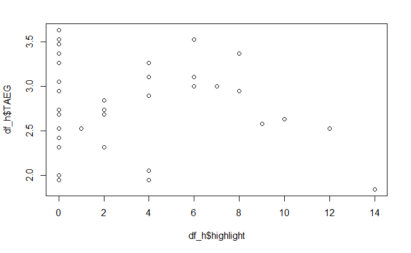

```r
plot(df_h$highlight, df_h$TAEG)
```

##### positive correlation with SUS

Participants who used the highlights function more frequently have rated the prototype’s usability higher.

```r
cor.test(df_h$SUS, df_h$highlight)
```

```
    Pearson's product-moment correlation

data:  df_h$SUS and df_h$highlight
t = 3.7631, df = 32, p-value = 0.000678
alternative hypothesis: true correlation is not equal to 0
95 percent confidence interval:
 0.2654225 0.7513172
sample estimates:
      cor
0.5538742
```

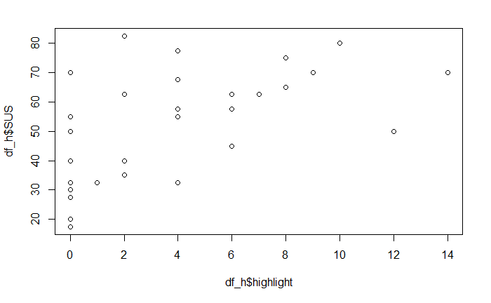

```r
plot(df_h$highlight, df_h$SUS)
```

##### NASA-TLX (n.s.)

```r
df_h$NASATLX_mean <- rowMeans(df_h[,c("NASATLX_1", "NASATLX_2", "NASATLX_3", "NASATLX_4")])
cor.test(df_h$NASATLX_mean, df_h$highlight)
```

```
    Pearson's product-moment correlation

data:  df_h$NASATLX_mean and df_h$highlight
t = -1.6694, df = 32, p-value = 0.1048
alternative hypothesis: true correlation is not equal to 0
95 percent confidence interval:
 -0.56694768  0.06095105
sample estimates:
       cor
-0.2830487
```

```r
cor.test(df_h$NASATLX_2, df_h$`highlights_trial 1`)
```

```
    Pearson's product-moment correlation

data:  df_h$NASATLX_2 and df_h$`highlights_trial 1`
t = -1.3465, df = 32, p-value = 0.1876
alternative hypothesis: true correlation is not equal to 0
95 percent confidence interval:
 -0.5283521  0.1156635
sample estimates:
       cor
-0.2315592
```

```r
cor.test(df_h$NASATLX_3, df_h$`highlights_trial 2`)
```

```
    Pearson's product-moment correlation

data:  df_h$NASATLX_3 and df_h$`highlights_trial 2`
t = -1.1198, df = 32, p-value = 0.2711
alternative hypothesis: true correlation is not equal to 0
95 percent confidence interval:
 -0.4995450  0.1541027
sample estimates:
       cor
-0.1941823
```

```r
cor.test(df_h$NASATLX_4, df_h$`highlights_trial 3`)
```

```
    Pearson's product-moment correlation

data:  df_h$NASATLX_4 and df_h$`highlights_trial 3`
t = -0.61954, df = 32, p-value = 0.5399
alternative hypothesis: true correlation is not equal to 0
95 percent confidence interval:
 -0.4311618  0.2380604
sample estimates:
       cor
-0.1088697
```

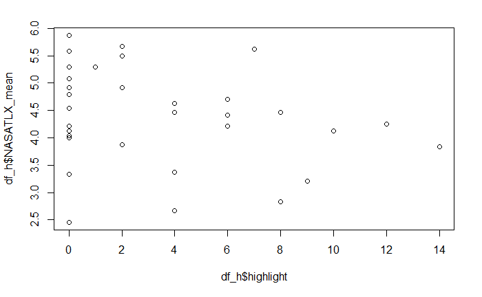

```r
plot(df_h$highlight, df_h$NASATLX_mean)
```

### Compare participants with high versus low usage of the highlights functions.

We compare participants who have not used the prototype in every trial vs. participants who have used the prototype at least once in every trial, as well as participants who have used the prototype more than average vs. less than average.

```r
#categorize participants
df_h$usage_every_trial <- ifelse((df_h$`highlights_trial 1` == 0 | df_h$`highlights_trial 2` == 0 | df_h$`highlights_trial 3` == 0), 0, 1)
df_h$usage_every_trial <- as.factor(df_h$usage_every_trial)
df_h$usage_above_average <- ifelse((df_h$highlight > 3), 1, 0)
df_h$usage_above_average <- as.factor(df_h$usage_above_average)
```

#### TA-EG (n.s.)

There is no difference in participants’ TA-EG values for participants with low versus high usage.

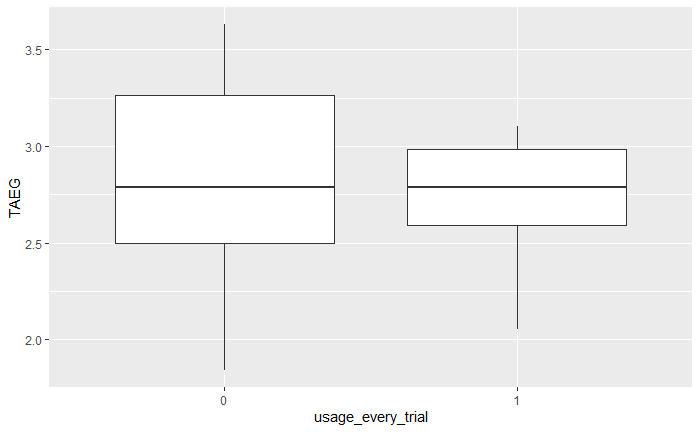

```r
par(mfrow = c(2,1))

ggplot(aes(y = TAEG, x = usage_every_trial), data = df_h) + geom_boxplot()
```

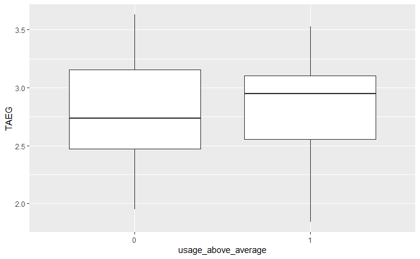

```r
ggplot(aes(y = TAEG, x = usage_above_average), data = df_h) + geom_boxplot()
```

```r
kruskal.test(df_h$TAEG, df_h$usage_every_trial)
```

```
    Kruskal-Wallis rank sum test

data:  df_h$TAEG and df_h$usage_every_trial
Kruskal-Wallis chi-squared = 0.086409, df = 1, p-value = 0.7688
```

```r
kruskal.test(df_h$TAEG, df_h$usage_above_average)
```

```
    Kruskal-Wallis rank sum test

data:  df_h$TAEG and df_h$usage_above_average
Kruskal-Wallis chi-squared = 0.043401, df = 1, p-value = 0.835
```

Participants who used the highlights function in every trial (/ above average) rated the prototype’s usability higher than those who did not use the function in every trial (/ who used it below average).

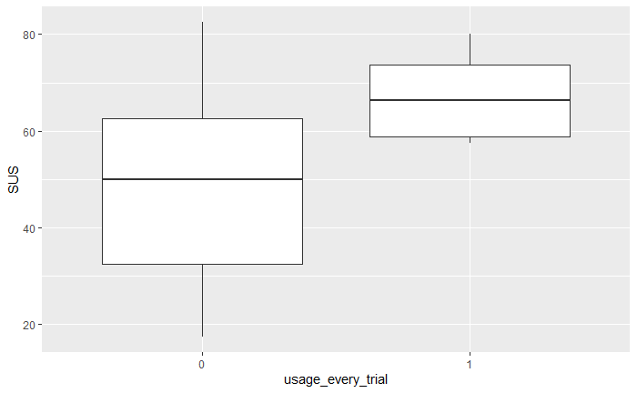

```r
ggplot(aes(y = SUS, x = usage_every_trial), data = df_h) + geom_boxplot()
```

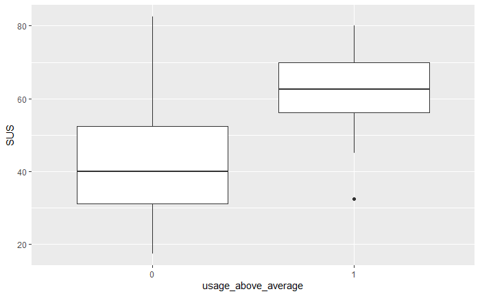

```r
ggplot(aes(y = SUS, x = usage_above_average), data = df_h) + geom_boxplot()
```

```r
kruskal.test(df_h$SUS, df_h$usage_every_trial)
```

```
    Kruskal-Wallis rank sum test

data:  df_h$SUS and df_h$usage_every_trial
Kruskal-Wallis chi-squared = 6.2038, df = 1, p-value = 0.01275
```

```r
kruskal.test(df_h$SUS, df_h$usage_above_average)
```

```
    Kruskal-Wallis rank sum test

data:  df_h$SUS and df_h$usage_above_average
Kruskal-Wallis chi-squared = 9.7922, df = 1, p-value = 0.001753
```

##### NASA-TLX

There are no significant differences in NASA-TLX for participants with low versus high usage of the function.

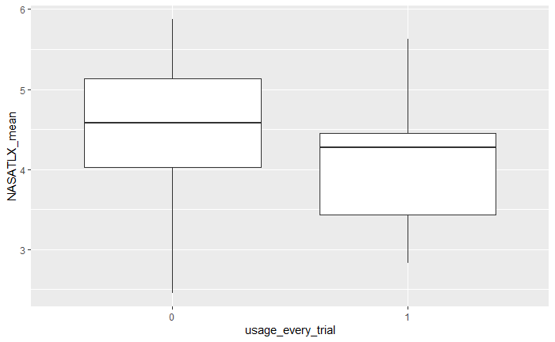

```r
ggplot(aes(y = NASATLX_mean, x = usage_every_trial), data = df_h) + geom_boxplot()
```

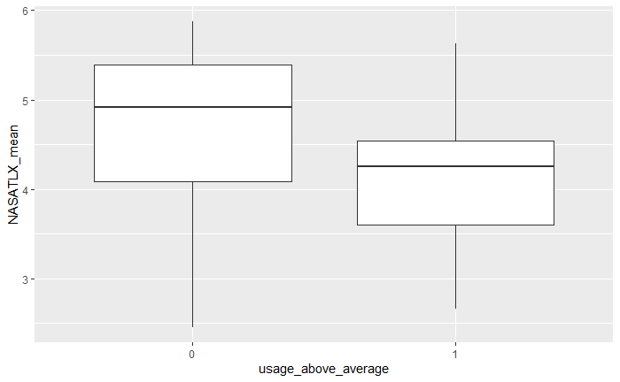

```r
ggplot(aes(y = NASATLX_mean, x = usage_above_average), data = df_h) + geom_boxplot()
```

```r
kruskal.test(df_h$NASATLX_mean, df_h$usage_every_trial)
```

```
    Kruskal-Wallis rank sum test

data:  df_h$NASATLX_mean and df_h$usage_every_trial
Kruskal-Wallis chi-squared = 0.98881, df = 1, p-value = 0.32
```

```r
kruskal.test(df_h$NASATLX_mean, df_h$usage_above_average)
```

```
    Kruskal-Wallis rank sum test

data:  df_h$NASATLX_mean and df_h$usage_above_average
Kruskal-Wallis chi-squared = 3.7095, df = 1, p-value = 0.0541
```

```r
table(df_h$usage_above_average)
```

```
 0  1
19 15
```

```r
table(df_h$usage_every_trial)
```

```
 0  1
28  6
```

### Analysis of performance

There seem to be no differences for performance for participants who used the highlight function a every trial (/ above average) vs. not every trial (/below average).

```r
df_perf$usage_every_trial <- ifelse((df_perf$`highlights_trial 1` == 0 | df_perf$`highlights_trial 2` == 0 | df_perf$`highlights_trial 3` == 0), 0, 1)
df_perf$usage_every_trial <- as.factor(df_perf$usage_every_trial)
mean_highlight_p <- mean(df_perf$highlight)
df_perf$usage_above_average <- ifelse((df_perf$highlight > mean_highlight_p), 1, 0)
df_perf$usage_above_average <- as.factor(df_perf$usage_above_average)
```

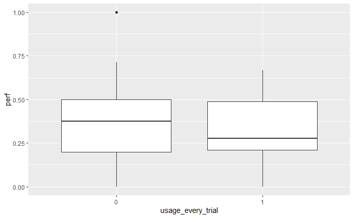

```r
ggplot(aes(y = perf, x = usage_every_trial), data = df_perf) + geom_boxplot()
```

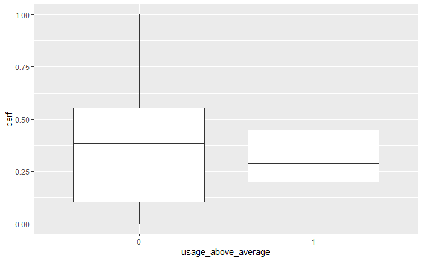

```r
ggplot(aes(y = perf, x = usage_above_average), data = df_perf) + geom_boxplot()
```

```r
cor.test(df_perf$perf, df_perf$highlight)
```

```
    Pearson's product-moment correlation

data:  df_perf$perf and df_perf$highlight
t = -0.4029, df = 31, p-value = 0.6898
alternative hypothesis: true correlation is not equal to 0
95 percent confidence interval:
 -0.4054370  0.2780239
sample estimates:
        cor
-0.07217395
```

```r
kruskal.test(df_perf$perf, df_perf$usage_every_trial)
```

```
    Kruskal-Wallis rank sum test

data:  df_perf$perf and df_perf$usage_every_trial
Kruskal-Wallis chi-squared = 0.07876, df = 1, p-value = 0.779
```

```r
kruskal.test(df_perf$perf, df_perf$usage_above_average)
```

```
    Kruskal-Wallis rank sum test

data:  df_perf$perf and df_perf$usage_above_average
Kruskal-Wallis chi-squared = 0.064321, df = 1, p-value = 0.7998
```